# Acheta Desiccation

- Show All Code
- Hide All Code
- View Source

Tissue wet mass

Author

Affiliation

Jacinta Kong

Department of Biology, Carleton Univeristy, Canada

Published

October 14, 2026

# 1 Introduction

Aim 1: To determine whether crickets are losing fluid from tissue  
Aim 2: To determine whether crickets are mobilizing lipid stores

1. Control crickets 0 h of desiccation
2. 3 h of desiccation
3. 6 h of desiccation
4. 18 h of desiccation
5. 18 h of desiccation, then 6 h with water, no food (rehydration)
6. 18 h of desiccation, then 6 h with water **and** food (fed)

Treatment 6 was added because there is a strong effect of rehydration that is also explained by starvation.

# 2 Setup

## 2.1 Load data

**Note: Variable labels are not exactly the same as the other datasets but are equivalent.**

```r
# Load mass data
tissue_data <- read_excel("data/Desiccation 2025/Tissue water content/TissueWaterData.xlsx", sheet = "mass") %>%
  mutate(Desiccation_time = ifelse(Time == 24, 18, Time),
         Time_treatment = factor(Time_treatment, levels = c("0", "3", "6","18", "24_fed", "24_starved")),
         Time_plot = ifelse(Time_treatment == "24_fed", 25, Time),
         Start_mass = Start.Cricket - Start.Container,
         Whole_animal_wet_mass = case_when(Time == 0 ~ Start_mass,
                              .default = Beadmill.Cricket - Beadmill),
         Rehydrated_transfer_mass = ifelse(Time == 24, Transfer.Cricket - Transfer.Container, NA),
         Tissue_wet_mass = Beadmill.NoHaemolymph - Beadmill,
         Tissue_dry_mass = Beadmill.DryCricket - Beadmill,
         Percent_change = case_when(Time == 0 ~ NA,
                                    Time == 24 ~ 100 - (Rehydrated_transfer_mass / Start_mass) * 100,
                                    .default = 100 - (Whole_animal_wet_mass / Start_mass) * 100),
         Total_water_content = ((Start_mass - Tissue_dry_mass) / Start_mass) * 100,
         # Water lost during desiccation (%)
         Relative_water_loss = (Percent_change /  Total_water_content) * 100,
         # Calculate water loss rates
         Mass_change_rate = ifelse(Time == 0, NA, Percent_change / Desiccation_time) # %/h
  )

# Calculate water content in mg. Adds up to Body_water
tissue_data <- tissue_data %>%
  mutate(
    # Total amount of water in body
    Body_water = Start_mass - Tissue_dry_mass,
    # Water lost during desiccation
    Lost_water = Start_mass - Whole_animal_wet_mass,
    # Water in tissue post-desiccation
    Tissue_water = Tissue_wet_mass - Tissue_dry_mass,
    # Haemolymph post-desiccation
    Haem_volume = Whole_animal_wet_mass - Tissue_wet_mass)

# Calculate proportion relative to total amount of body water
tissue_data <- tissue_data %>%
  mutate(
    # Water lost during desiccation
    Lost_prop = ((Lost_water / Body_water) * 100),
    # Water in tissue post-desiccation
    Tissue_prop =  ((Tissue_water / Body_water) * 100),
    # Haemolymph post-desiccation
    Haem_prop =  ((Haem_volume / Body_water) * 100))

# Standardise tissue and haemolymph changes relative to controls
baseline <- tissue_data %>%
  group_by(Sex) %>%
  filter(Time == 0) %>%
  summarise(mean_tissue = mean(Tissue_prop),
            mean_haem = mean(Haem_prop)) %>%
  data.frame(row.names = c("F", "M"))

tissue_data <- tissue_data %>%
  mutate(rel_tissue = ifelse(Sex == "Female", Tissue_prop / baseline["F","mean_tissue"],
                             Tissue_prop / baseline["M","mean_tissue"]),
         rel_haem = ifelse(Sex == "Female", Haem_prop / baseline["F","mean_haem"],
                             Haem_prop / baseline["M","mean_haem"]),
         rel_loss = (Body_water - Lost_water) / Body_water,
         diff_tissue = ifelse(Sex == "Female", Tissue_prop - baseline["F","mean_tissue"],
                             Tissue_prop - baseline["M","mean_tissue"]),
         diff_haem = ifelse(Sex == "Female", Haem_prop - baseline["F","mean_haem"],
                             Haem_prop - baseline["M","mean_haem"]))
```

## 2.2 Rehydrated crickets

Calculate relative mass change during recovery to compare with other datasets.

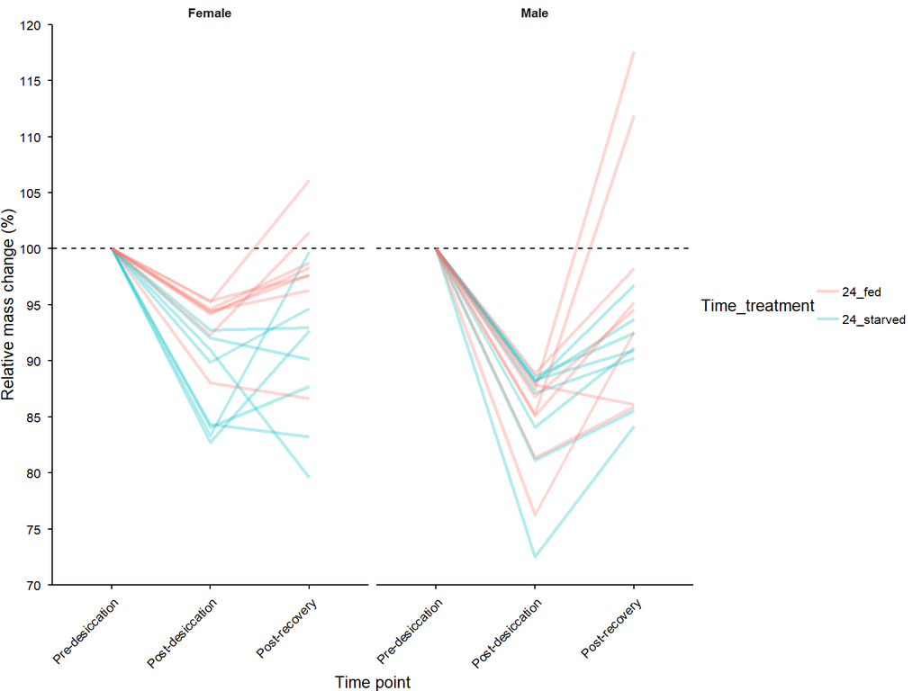

```r
rehydration_tissue <- tissue_data %>%
  filter(Time == 24) %>%
  mutate(Percent_change = 100 - (Rehydrated_transfer_mass / Start_mass) * 100,
         Percent_change_recovery = (Whole_animal_wet_mass / Start_mass) * 100) %>%
  select(Cricket_ID, Sex, Time_treatment, Percent_change, Percent_change_recovery) %>%
  mutate(Start_Percent = 100,
         Percent_change = 100 - Percent_change) %>%
  pivot_longer(contains("Percent"), names_to = "Timepoint", values_to = "Change") %>%
  mutate(Experiment = "Tissue",
    Timepoint = factor(Timepoint, levels = c("Start_Percent", "Percent_change", "Percent_change_recovery")))

save(tissue_data, rehydration_tissue, file = "data/Desiccation 2025/tissue.Rdata")

ggplot(rehydration_tissue, aes(Timepoint, Change, group = Cricket_ID, colour = Time_treatment)) +
  geom_hline(yintercept = 100, linetype = 2) +
  geom_line(linewidth = 1, alpha = 0.3) +
  theme(legend.position = "right") +
  ylab("Relative mass change (%)") +
  scale_y_continuous(breaks = seq(0, 120, 5), limits = c(70, 120), expand = c(0, 0)) +
  scale_x_discrete(name = "Time point", labels = c("Pre-desiccation", "Post-desiccation", "Post-recovery")) +
  facet_grid(~Sex) +
  theme(legend.position = "right",
        axis.text.x = element_text(angle = 45, hjust = 1))
```

# 3 Changes in wet mass

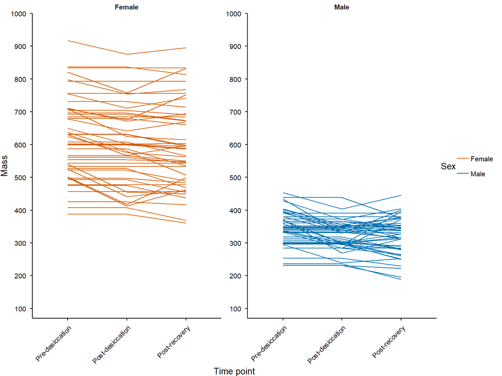

```r
tissue_data %>%
  mutate(Rehydrated_transfer_mass = ifelse(is.na(Rehydrated_transfer_mass), Start_mass, Rehydrated_transfer_mass)) %>%
  select(Cricket_ID, Sex, Time_treatment,Start_mass, Whole_animal_wet_mass, Rehydrated_transfer_mass) %>%
  pivot_longer(cols = matches(c("Start_mass", "Whole_animal_wet_mass", "Rehydrated_transfer_mass")), names_to = "Timepoint", values_to = "Mass") %>%
  mutate(Timepoint = factor(Timepoint, levels = c("Start_mass", "Rehydrated_transfer_mass", "Whole_animal_wet_mass"))) %>%
  ggplot(aes(Timepoint, Mass, colour = Sex, group = Cricket_ID)) +
  geom_line() +
  facet_wrap(~Sex, scales = "free") +
  scale_colour_manual(values = sex_pal) +
  scale_shape_manual(values = sex_point) +
scale_y_continuous(breaks = seq(0, 1000, 100), limits = c(70, 1000), expand = c(0, 0)) +
  scale_x_discrete(name = "Time point", labels = c("Pre-desiccation", "Post-desiccation", "Post-recovery")) +
  theme(legend.position = "right",
        axis.text.x = element_text(angle = 45, hjust = 1))
```

# 4 Are crickets losing haemolymph?

Measured gravimetrically. Indicating preferential loss or replenishment of extracellular fluid.

```r
mean_vol <- tissue_data %>%
  group_by(Time_treatment, Sex, Time_plot) %>%
  summarise(n = n(),
            mean = mean(Haem_volume),
            se = sd(Haem_volume) / sqrt(n()),
            cv = (sd(Haem_volume) / mean) * 100)
knitr::kable(mean_vol, digits = 3)
```

| Time_treatment | Sex | Time_plot | n | mean | se | cv |
| --- | --- | --- | --- | --- | --- | --- |
| 0 | Female | 0 | 8 | 119.959 | 16.482 | 38.863 |
| 0 | Male | 0 | 8 | 68.641 | 8.948 | 36.873 |
| 3 | Female | 3 | 8 | 97.748 | 6.951 | 20.114 |
| 3 | Male | 3 | 8 | 59.544 | 6.314 | 29.994 |
| 6 | Female | 6 | 8 | 93.917 | 7.334 | 22.086 |
| 6 | Male | 6 | 8 | 41.029 | 2.696 | 18.584 |
| 18 | Female | 18 | 8 | 76.525 | 7.323 | 27.066 |
| 18 | Male | 18 | 8 | 36.468 | 3.598 | 27.908 |
| 24_fed | Female | 25 | 8 | 138.207 | 7.479 | 15.305 |
| 24_fed | Male | 25 | 8 | 61.229 | 4.841 | 22.363 |
| 24_starved | Female | 24 | 8 | 100.325 | 4.117 | 11.608 |
| 24_starved | Male | 24 | 8 | 59.191 | 4.254 | 20.326 |

```r
mean_vol_starved <- filter(mean_vol, Time_treatment != "24_fed")
mean_vol_fed <- filter(mean_vol, Time_treatment %in% c("18", "24_fed"))
```

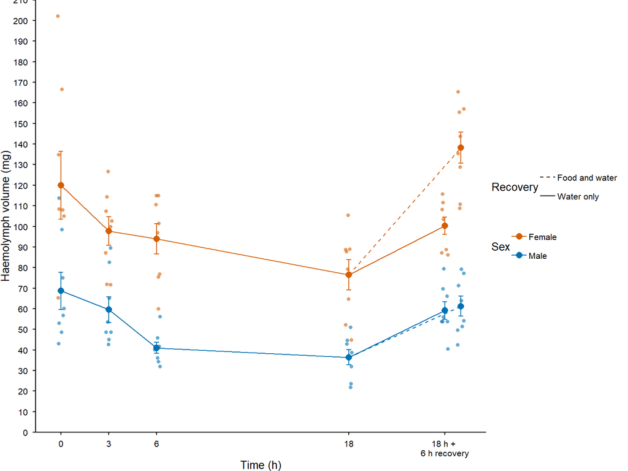

Haemolymph volume (mg) of female (orange) and male (blue) crickets after desiccation (hours). Error bars are standard error about the mean.

```r
p_volume <- ggplot() +
  geom_point(data = tissue_data, aes(Time_plot, Haem_volume, shape = Sex, colour = Sex), position = position_jitter(width = 0.2, height = 0), alpha = 0.6) +
     # line for starved crickets
  geom_line(data = mean_vol_starved, aes(Time_plot, mean, colour = Sex, linetype = "Starved")) +
   # Line for fed crickets
  geom_line(data = mean_vol_fed, aes(Time_plot, mean, colour = Sex, linetype = "Fed")) +
  geom_point(data = mean_vol, aes(Time_plot, mean, colour = Sex),
             size = 2.5, shape = 16) +
  geom_errorbar(data = mean_vol, aes(Time_plot, ymin = mean - se, ymax = mean + se,
                                     colour = Sex), width = 0.3) +
  scale_colour_manual(values = sex_pal) +
  scale_shape_manual(values = sex_point) +
    scale_linetype_manual(name = "Recovery", values = c("Fed" = 2, "Starved" = 1), labels = c("Food and water", "Water only")) +
  scale_y_continuous(name = "Haemolymph volume (mg)", limits = c(0, 210), expand = c(0,0), breaks = seq(0, 250, 10)) +
  scale_x_continuous(name = "Time (h)", breaks = c(0, 3, 6, 18, 24), labels = c("0", "3", "6", "18", "18 h + \n6 h recovery"), limits = c(-0.3, 25.3)) +
  theme(legend.position = "right")

p_volume
```

## 4.1 Stats: Haem volume

- No interaction between time and sex. The interaction is dropped from the model.
- No differences between sexes. Sex is dropped from the model.
- Crickets decrease haemolymph volume after 6 hours then recover volume.
- No change within 3 hours.
- No effect of feeding during recovery.

```r
hv_mod <- lm(Haem_volume ~ Start_mass + Time_treatment, tissue_data)

anova(hv_mod)
```

```
Analysis of Variance Table

Response: Haem_volume
               Df Sum Sq Mean Sq  F value                Pr(>F)
Start_mass      1  89679   89679 304.7895 < 0.00000000000000022 ***
Time_treatment  5   7610    1522   5.1729             0.0003262 ***
Residuals      89  26187     294
---
Signif. codes:  0 '***' 0.001 '**' 0.01 '*' 0.05 '.' 0.1 ' ' 1
```

```r
pairs(emmeans(hv_mod, ~ Time_treatment), adjust = "Tukey") %>%
  broom::tidy() %>%
  arrange(.$adj.p.value)
```

```
# A tibble: 15 × 8
   term           contrast            null.value   estimate std.error    df
   <chr>          <chr>                    <dbl>      <dbl>     <dbl> <dbl>
 1 Time_treatment 0 - 6                        0  26.30190   6.064669    89
 2 Time_treatment 0 - 18                       0  23.32328   6.130749    89
 3 Time_treatment 3 - 6                        0  17.44061   6.077035    89
 4 Time_treatment 6 - 24_fed                   0 -16.22133   6.145514    89
 5 Time_treatment 6 - 24_starved               0 -15.08069   6.067061    89
 6 Time_treatment 3 - 18                       0  14.46200   6.083302    89
 7 Time_treatment 18 - 24_fed                  0 -13.24272   6.343348    89
 8 Time_treatment 18 - 24_starved              0 -12.10207   6.103968    89
 9 Time_treatment 0 - 24_starved               0  11.22121   6.068079    89
10 Time_treatment 0 - 24_fed                   0  10.08057   6.140331    89
11 Time_treatment 0 - 3                        0   8.861288  6.079205    89
12 Time_treatment 6 - 18                       0  -2.978618  6.126063    89
```

[output cut: 20 more lines]

# 5 Are crickets losing tissue water content?

Or are they preferentially losing water from their extracellular spaces instead.

Crickets are losing whole body wet mass during desiccation and their tissue wet mass. Their haemolymph mass is decreasing then increasing. Their dry mass was lower than the other treatments, so proportionally, they have lost more water from their tissue after drying in the oven, giving higher tissue water content.

```r
mean_tissue <- tissue_data %>%
  group_by(Time_treatment, Sex, Time_plot) %>%
  summarise(n = n(),
            mean = mean(Tissue_water),
            se = sd(Tissue_water) / sqrt(n()),
            cv = (sd(Tissue_water) / mean) * 100)
knitr::kable(mean_tissue, digits = 3)
```

| Time_treatment | Sex | Time_plot | n | mean | se | cv |
| --- | --- | --- | --- | --- | --- | --- |
| 0 | Female | 0 | 8 | 301.059 | 24.152 | 22.691 |
| 0 | Male | 0 | 8 | 192.669 | 4.955 | 7.275 |
| 3 | Female | 3 | 8 | 269.088 | 15.540 | 16.335 |
| 3 | Male | 3 | 8 | 173.753 | 8.608 | 14.013 |
| 6 | Female | 6 | 8 | 320.468 | 17.369 | 15.329 |
| 6 | Male | 6 | 8 | 166.589 | 7.684 | 13.047 |
| 18 | Female | 18 | 8 | 224.739 | 13.938 | 17.542 |
| 18 | Male | 18 | 8 | 155.534 | 13.443 | 24.447 |
| 24_fed | Female | 25 | 8 | 352.786 | 14.822 | 11.884 |
| 24_fed | Male | 25 | 8 | 218.522 | 6.554 | 8.483 |
| 24_starved | Female | 24 | 8 | 265.801 | 8.944 | 9.517 |
| 24_starved | Male | 24 | 8 | 192.528 | 8.574 | 12.595 |

```r
mean_tissue_starved <- filter(mean_tissue, Time_treatment != "24_fed")
mean_tissue_fed <- filter(mean_tissue, Time_treatment %in% c("18", "24_fed"))
```

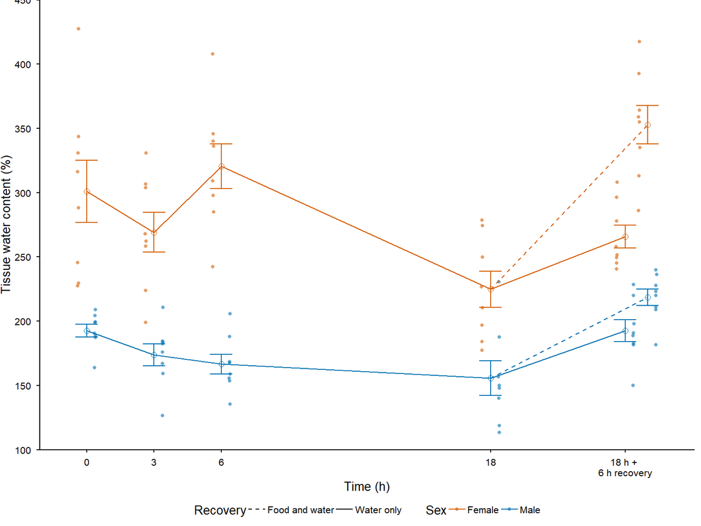

```r
p_water <- ggplot() +
  geom_point(data = tissue_data, aes(Time_plot, Tissue_water, shape = Sex, colour = Sex), position = position_jitterdodge(jitter.height = 0, jitter.width = 0.1, dodge = 1.5), alpha = 0.6, stroke = NA) +
   # line for starved crickets
  geom_line(data = mean_tissue_starved, aes(Time_plot, mean, colour = Sex, linetype = "Starved"), linewidth = 0.5) +
   # Line for fed crickets
  geom_line(data = mean_tissue_fed, aes(Time_plot, mean, colour = Sex, linetype = "Fed"), linewidth = 0.5) +
  geom_point(data = mean_tissue, aes(Time_plot, mean, colour = Sex),
             size = 2, shape = 1, show.legend = FALSE) +
  geom_errorbar(data = mean_tissue, aes(Time_plot, ymin = mean - se, ymax = mean + se,
                                     colour = Sex), width = 1, linewidth = 0.5) +
  scale_colour_manual(values = sex_pal) +
  scale_shape_manual(values = sex_point) +
  scale_linetype_manual(name = "Recovery", values = c("Fed" = 2, "Starved" = 1), labels = c("Food and water", "Water only")) +
  scale_y_continuous(name = "Tissue water content (%)", limits = c(100, 450), expand = c(0,0), breaks = seq(0, 500, 50)) +
  scale_x_continuous(name = "Time (h)", breaks = c(0, 3, 6, 18, 24), labels = c("0", "3", "6", "18", "18 h + \n6 h recovery"))

p_water
```

```r
ggsave(p_water, dpi = 300, width = ppt_width, units = "mm", height = ppt_height, filename = "data/Desiccation 2025/figures/tissue_water.png")
```

## 5.1 Relative to body water

```r
body_mean_tissue <- tissue_data %>%
  group_by(Time_treatment, Sex, Time_plot) %>%
  summarise(.groups = "drop",
            n = n(),
            mean = mean(Tissue_prop),
            se = sd(Tissue_prop) / sqrt(n()),
            cv = (sd(Tissue_prop) / mean) * 100)
knitr::kable(body_mean_tissue, digits = 3)
```

| Time_treatment | Sex | Time_plot | n | mean | se | cv |
| --- | --- | --- | --- | --- | --- | --- |
| 0 | Female | 0 | 8 | 71.928 | 2.395 | 9.416 |
| 0 | Male | 0 | 8 | 74.218 | 2.446 | 9.321 |
| 3 | Female | 3 | 8 | 71.024 | 1.409 | 5.610 |
| 3 | Male | 3 | 8 | 70.380 | 1.516 | 6.093 |
| 6 | Female | 6 | 8 | 72.865 | 1.253 | 4.865 |
| 6 | Male | 6 | 8 | 71.387 | 1.305 | 5.171 |
| 18 | Female | 18 | 8 | 65.973 | 1.665 | 7.139 |
| 18 | Male | 18 | 8 | 65.375 | 1.094 | 4.732 |
| 24_fed | Female | 25 | 8 | 69.651 | 2.081 | 8.452 |
| 24_fed | Male | 25 | 8 | 76.229 | 4.314 | 16.007 |
| 24_starved | Female | 24 | 8 | 63.001 | 2.066 | 9.277 |
| 24_starved | Male | 24 | 8 | 67.397 | 1.744 | 7.319 |

```r
body_mean_tissue_starved <- filter(body_mean_tissue, Time_treatment != "24_fed")
body_mean_tissue_fed <- filter(body_mean_tissue, Time_treatment %in% c("18", "24_fed"))

p_relwater <- ggplot() +
  geom_point(data = tissue_data, aes(Time_plot, Tissue_prop, shape = Sex, colour = Sex), position = position_jitterdodge(jitter.height = 0, jitter.width = 0.1, dodge = 1.5), alpha = 0.6, stroke = NA) +
   # line for starved crickets
  geom_line(data = body_mean_tissue_starved, aes(Time_plot, mean, colour = Sex, linetype = "Starved"), linewidth = 0.5) +
   # Line for fed crickets
  geom_line(data = body_mean_tissue_fed, aes(Time_plot, mean, colour = Sex, linetype = "Fed"), linewidth = 0.5) +
  geom_point(data = body_mean_tissue, aes(Time_plot, mean, colour = Sex),
             size = 2, shape = 1, show.legend = FALSE) +
  geom_errorbar(data = body_mean_tissue, aes(Time_plot, ymin = mean - se, ymax = mean + se,
                                     colour = Sex), width = 1, linewidth = 0.5) +
  scale_colour_manual(values = sex_pal) +
  scale_shape_manual(values = sex_point) +
  scale_linetype_manual(name = "Recovery", values = c("Fed" = 2, "Starved" = 1), labels = c("Food and water", "Water only")) +
  scale_y_continuous(name = "Tissue water (% body water)", limits = c(50, 100), expand = c(0,0), breaks = seq(0, 100, 10)) +
  scale_x_continuous(name = "Time (h)", breaks = c(0, 3, 6, 18, 24), labels = c("0", "3", "6", "18", "18 h + \n6 h recovery"))

tissue_mod <- lm(Tissue_prop ~ Time_treatment + Sex, tissue_data)
anova(tissue_mod)
```

```
Analysis of Variance Table

Response: Tissue_prop
               Df Sum Sq Mean Sq F value    Pr(>F)
Time_treatment  5 1037.7 207.538  5.7634 0.0001181 ***
Sex             1   74.1  74.118  2.0583 0.1548866
Residuals      89 3204.9  36.010
---
Signif. codes:  0 '***' 0.001 '**' 0.01 '*' 0.05 '.' 0.1 ' ' 1
```

```r
pairs(emmeans(tissue_mod, ~ Time_treatment), adjust = "Tukey") %>%
  broom::tidy() %>%
  arrange(adj.p.value) %>%
  filter(adj.p.value <= 0.05)
```

```
# A tibble: 6 × 8
  term           contrast            null.value  estimate std.error    df
  <chr>          <chr>                    <dbl>     <dbl>     <dbl> <dbl>
1 Time_treatment 0 - 24_starved               0  7.874510  2.121609    89
2 Time_treatment 24_fed - 24_starved          0  7.741247  2.121609    89
3 Time_treatment 0 - 18                       0  7.399520  2.121609    89
4 Time_treatment 18 - 24_fed                  0 -7.266258  2.121609    89
5 Time_treatment 6 - 24_starved               0  6.927129  2.121609    89
6 Time_treatment 6 - 18                       0  6.452140  2.121609    89
  statistic adj.p.value
      <dbl>       <dbl>
1  3.711575 0.004688982
2  3.648762 0.005752759
3  3.487693 0.009589348
4 -3.424881 0.01164098
5  3.265036 0.01879598
6  3.041154 0.03545740
```

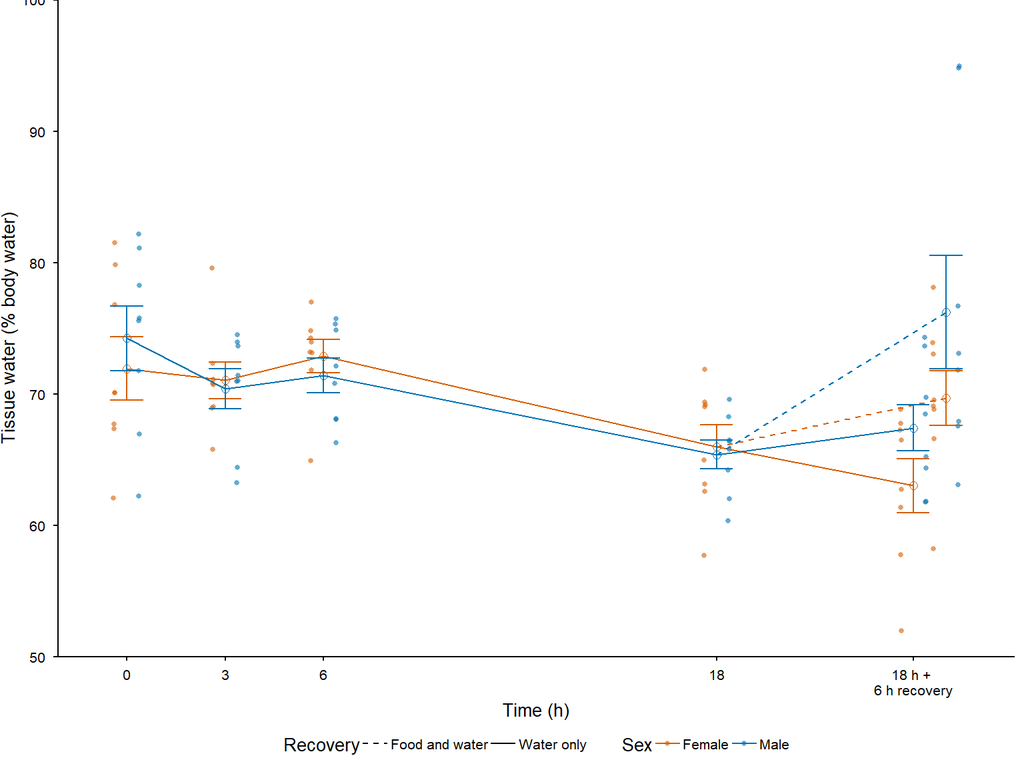

```r
p_relwater
```

```r
save(p_relwater, file = "data/Desiccation 2025/figures/p_relwater.rdata")
ggsave(p_relwater, dpi = 300, width = ppt_width, units = "mm", height = ppt_height, filename = "data/Desiccation 2025/figures/relative_tissue_water.png")
```

## 5.2 Ratio to control

```r
rel_mean_tissue <- tissue_data %>%
  group_by(Time_treatment, Time_plot) %>%
  summarise(.groups = "drop",
            n = n(),
            mean = mean(rel_tissue),
            se = sd(rel_tissue) / sqrt(n()),
            cv = (sd(rel_tissue) / mean) * 100,
            mean_haem = mean(rel_haem),
            se_haem = sd(rel_haem) / sqrt(n()))

knitr::kable(rel_mean_tissue, digits = 3)
```

| Time_treatment | Time_plot | n | mean | se | cv | mean_haem | se_haem |
| --- | --- | --- | --- | --- | --- | --- | --- |
| 0 | 0 | 16 | 1.000 | 0.023 | 9.051 | 1.000 | 0.062 |
| 3 | 3 | 16 | 0.968 | 0.015 | 6.023 | 0.924 | 0.040 |
| 6 | 6 | 16 | 0.987 | 0.014 | 5.534 | 0.726 | 0.038 |
| 18 | 18 | 16 | 0.899 | 0.014 | 6.257 | 0.698 | 0.046 |
| 24_fed | 25 | 16 | 0.998 | 0.032 | 12.937 | 0.899 | 0.045 |
| 24_starved | 24 | 16 | 0.892 | 0.018 | 8.253 | 0.824 | 0.029 |

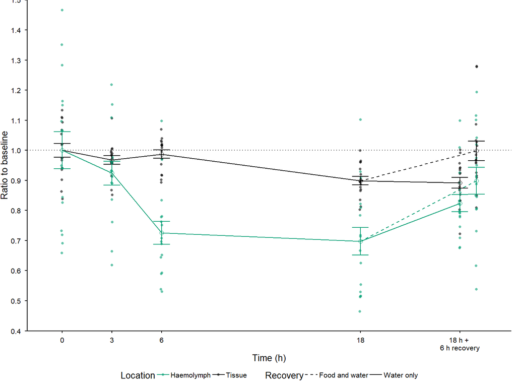

```r
rel_mean_tissue_starved <- filter(rel_mean_tissue, Time_treatment != "24_fed")
rel_mean_tissue_fed <- filter(rel_mean_tissue, Time_treatment %in% c("18", "24_fed"))

rel_water <- ggplot() +
  geom_hline(yintercept = 1, linetype = 3, colour = "grey30") +
  geom_point(data = tissue_data, aes(Time_plot, rel_tissue, colour = "Tissue"), position = position_jitterdodge(jitter.height = 0, jitter.width = 0.1, dodge = 1.5), alpha = 0.6, stroke = NA) +
  geom_point(data = tissue_data, aes(Time_plot, rel_haem, colour = "Haemolymph"), position = position_jitterdodge(jitter.height = 0, jitter.width = 0.1, dodge = 1.5), alpha = 0.6, stroke = NA) +
   # line for starved crickets
  geom_line(data = rel_mean_tissue_starved, aes(Time_plot, mean, colour = "Tissue", linetype = "Starved"), linewidth = 0.5) +
   # Line for fed crickets
  geom_line(data = rel_mean_tissue_fed, aes(Time_plot, mean, colour = "Tissue", linetype = "Fed"), linewidth = 0.5) +
  # line for starved crickets - haem
  geom_line(data = rel_mean_tissue_starved, aes(Time_plot, mean_haem, colour = "Haemolymph", linetype = "Starved"), linewidth = 0.5) +
   # Line for fed crickets - haem
  geom_line(data = rel_mean_tissue_fed, aes(Time_plot, mean_haem, colour = "Haemolymph", linetype = "Fed"), linewidth = 0.5) +
  geom_point(data = rel_mean_tissue, aes(Time_plot, mean, colour = "Tissue"),
             size = 2, shape = 1, show.legend = FALSE) +
  geom_errorbar(data = rel_mean_tissue, aes(Time_plot, ymin = mean - se, ymax = mean + se,
                                     colour = "Tissue"), width = 1, linewidth = 0.5) +
  geom_point(data = rel_mean_tissue, aes(Time_plot, mean_haem, colour = "Haemolymph"),
             size = 2, shape = 1, show.legend = FALSE) +
  geom_errorbar(data = rel_mean_tissue, aes(Time_plot, ymin = mean_haem - se_haem, ymax = mean_haem + se_haem,
                                     colour = "Haemolymph"), width = 1, linewidth = 0.5) +
    scale_colour_manual(name = "Location", values = c("Tissue" = "black", "Haemolymph" = "#009E73")) +
  scale_y_continuous(name = "Ratio to baseline", limits = c(0.4, 1.5), expand = c(0,0), breaks = seq(0, 2, 0.1)) +
  scale_x_continuous(name = "Time (h)", breaks = c(0, 3, 6, 18, 24), labels = c("0", "3", "6", "18", "18 h + \n6 h recovery")) +
    scale_linetype_manual(name = "Recovery", values = c("Fed" = 2, "Starved" = 1), labels = c("Food and water", "Water only"))

rel_water
```

```r
save(rel_water, file = "data/Desiccation 2025/figures/p_stdwater.rdata")
```

## 5.3 Difference from control

No effect of sex so dropped

```r
diff_mean_tissue <- tissue_data %>%
  group_by(Time_treatment, Time_plot) %>%
  summarise(.groups = "drop",
            n = n(),
            mean = mean(diff_tissue),
            se = sd(diff_tissue) / sqrt(n()),
            cv = (sd(diff_tissue) / mean) * 100,
            mean_haem = mean(diff_haem),
            se_haem = sd(diff_haem) / sqrt(n()),
            mean_loss = -mean(Lost_prop),
            se_loss =  sd(Lost_prop) / sqrt(n()))

knitr::kable(diff_mean_tissue, digits = 3)
```

| Time_treatment | Time_plot | n | mean | se | cv | mean_haem | se_haem | mean_loss | se_loss |
| --- | --- | --- | --- | --- | --- | --- | --- | --- | --- |
| 0 | 0 | 16 | 0.000 | 1.653 | 372306557065628480.000 | 0.000 | 1.653 | 0.000 | 0.000 |
| 3 | 3 | 16 | -2.371 | 1.069 | -180.332 | -2.050 | 1.051 | -4.421 | 0.497 |
| 6 | 6 | 16 | -0.947 | 1.000 | -422.335 | -7.342 | 1.004 | -8.289 | 1.025 |
| 18 | 18 | 16 | -7.400 | 1.032 | -55.791 | -8.018 | 1.205 | -15.417 | 1.228 |
| 24_fed | 25 | 16 | -0.133 | 2.379 | -7140.999 | -2.637 | 1.172 | -2.770 | 3.026 |
| 24_starved | 24 | 16 | -7.875 | 1.334 | -67.768 | -4.711 | 0.758 | -12.586 | 1.652 |

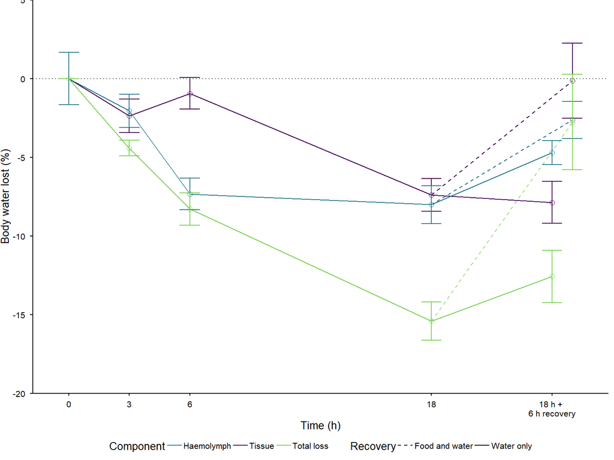

```r
diff_mean_tissue_starved <- filter(diff_mean_tissue, Time_treatment != "24_fed")
diff_mean_tissue_fed <- filter(diff_mean_tissue, Time_treatment %in% c("18", "24_fed"))

diff_pal <- viridis::viridis(3, begin = 0.8, end = 0, option = "D")

p_diff_water <- ggplot() +
  geom_hline(yintercept = 0, linetype = 3, colour = "grey30") +
  # geom_point(data = tissue_data, aes(Time_plot, diff_tissue, colour = "Tissue", ), position = position_jitter(height = 0, width = 0.1), alpha = 0.6, stroke = NA) +
  # geom_point(data = tissue_data, aes(Time_plot, diff_haem, colour = "Haemolymph"), position = position_jitter(height = 0, width = 0.1), alpha = 0.6, stroke = NA) +
  # geom_point(data = tissue_data, aes(Time_plot, -Lost_prop, colour = "Total loss"), position = position_jitter(height = 0, width = 0.1), alpha = 0.6, stroke = NA) +
   # line for starved crickets
  geom_line(data = diff_mean_tissue_starved, aes(Time_plot, mean, colour = "Tissue", linetype = "Starved"), linewidth = 0.5) +
   # Line for fed crickets
  geom_line(data = diff_mean_tissue_fed, aes(Time_plot, mean, colour = "Tissue", linetype = "Fed"), linewidth = 0.5) +
  # line for starved crickets - haem
  geom_line(data = diff_mean_tissue_starved, aes(Time_plot, mean_haem, colour = "Haemolymph", linetype = "Starved"), linewidth = 0.5) +
   # Line for fed crickets - haem
  geom_line(data = diff_mean_tissue_fed, aes(Time_plot, mean_haem, colour = "Haemolymph", linetype = "Fed"), linewidth = 0.5) +
  # line for starved crickets - total
  geom_line(data = diff_mean_tissue_starved, aes(Time_plot, mean_loss, colour = "Total loss", linetype = "Starved"), linewidth = 0.5) +
   # Line for fed crickets - total
  geom_line(data = diff_mean_tissue_fed, aes(Time_plot, mean_loss, colour = "Total loss", linetype = "Fed"), linewidth = 0.5) +
  geom_point(data = diff_mean_tissue, aes(Time_plot, mean, colour = "Tissue", ),
             size = 2, shape = 1, show.legend = FALSE) +
  # Error bar for tissue
  geom_errorbar(data = diff_mean_tissue, aes(Time_plot, ymin = mean - se, ymax = mean + se,
                                     colour = "Tissue"), width = 1, linewidth = 0.5) +
  # Point for haemolymph
  geom_point(data = diff_mean_tissue, aes(Time_plot, mean_haem, colour = "Haemolymph"),
             size = 2, shape = 1, show.legend = FALSE) +
  # Error bar for haemolymph
  geom_errorbar(data = diff_mean_tissue, aes(Time_plot, ymin = mean_haem - se_haem, ymax = mean_haem + se_haem,
                                     colour = "Haemolymph"), width = 1, linewidth = 0.5) +
  # Point for Total loss
  geom_point(data = diff_mean_tissue, aes(Time_plot, mean_loss, colour = "Total loss"),
             size = 2, shape = 1, show.legend = FALSE) +
  # Error bar for Total loss
  geom_errorbar(data = diff_mean_tissue, aes(Time_plot, ymin = mean_loss - se_loss, ymax = mean_loss + se_loss,
                                     colour = "Total loss"), width = 1, linewidth = 0.5) +
    scale_colour_manual(name = "Component", values = c("Tissue" = diff_pal[3], "Haemolymph" = diff_pal[2], "Total loss" = diff_pal[1])) +
  scale_y_continuous(name = "Body water lost (%)", limits = c(-20, 5), expand = c(0,0), breaks = seq(-30, 30, 5)) +
  scale_x_continuous(name = "Time (h)", breaks = c(0, 3, 6, 18, 24), labels = c("0", "3", "6", "18", "18 h + \n6 h recovery")) +
    scale_linetype_manual(name = "Recovery", values = c("Fed" = 2, "Starved" = 1), labels = c("Food and water", "Water only"))

p_diff_water
```

```r
ggsave(p_diff_water, dpi = 300, width = ppt_width, units = "mm", height = ppt_height, filename = "data/Desiccation 2025/figures/difference_tissue_water.png")
save(p_diff_water, file = "data/Desiccation 2025/figures/p_diffwater.rdata")
```

## 5.4 Stats: Tissue water content

```r
tissue_mod <- lm((Tissue_water/Whole_animal_wet_mass) ~ Time_treatment * Sex, tissue_data)

anova(tissue_mod)
```

```
Analysis of Variance Table

Response: (Tissue_water/Whole_animal_wet_mass)
                   Df   Sum Sq  Mean Sq  F value                Pr(>F)
Time_treatment      5 0.013636 0.002727   4.0116              0.002592 **
Sex                 1 0.185091 0.185091 272.2653 < 0.00000000000000022 ***
Time_treatment:Sex  5 0.004283 0.000857   1.2602              0.288832
Residuals          84 0.057105 0.000680
---
Signif. codes:  0 '***' 0.001 '**' 0.01 '*' 0.05 '.' 0.1 ' ' 1
```

```r
pairs(emmeans(tissue_mod, ~ Time_treatment * Sex), adjust = "Tukey", by = "Sex") %>%
  broom::tidy() %>%
  filter(adj.p.value <= 0.05)
```

```
# A tibble: 2 × 9
  Sex    term           contrast            null.value    estimate  std.error
  <chr>  <chr>          <chr>                    <dbl>       <dbl>      <dbl>
1 Female Time_treatment 3 - 24_starved               0 -0.03989069 0.01303667
2 Female Time_treatment 24_fed - 24_starved          0 -0.04190122 0.01303667
     df statistic adj.p.value
  <dbl>     <dbl>       <dbl>
1    84 -3.059884  0.03409684
2    84 -3.214105  0.02213049
```

### 5.4.1 Relative change

```r
anova(lm(rel_tissue ~ Time_treatment, tissue_data))
```

```
Analysis of Variance Table

Response: rel_tissue
               Df  Sum Sq  Mean Sq F value     Pr(>F)
Time_treatment  5 0.19422 0.038843  5.8528 0.00009989 ***
Residuals      90 0.59730 0.006637
---
Signif. codes:  0 '***' 0.001 '**' 0.01 '*' 0.05 '.' 0.1 ' ' 1
```

```r
pairs(emmeans(lm(rel_tissue ~ Time_treatment, tissue_data), ~ Time_treatment), adjust = "Tukey")
```

```
 contrast            estimate     SE df t.ratio p.value
 0 - 3                0.03214 0.0288 90   1.116  0.8735
 0 - 6                0.01256 0.0288 90   0.436  0.9979
 0 - 18               0.10098 0.0288 90   3.506  0.0090
 0 - 24_fed           0.00228 0.0288 90   0.079  1.0000
 0 - 24_starved       0.10801 0.0288 90   3.750  0.0041
 3 - 6               -0.01958 0.0288 90  -0.680  0.9838
 3 - 18               0.06883 0.0288 90   2.390  0.1709
 3 - 24_fed          -0.02986 0.0288 90  -1.037  0.9043
 3 - 24_starved       0.07587 0.0288 90   2.634  0.0996
 6 - 18               0.08841 0.0288 90   3.070  0.0327
 6 - 24_fed          -0.01028 0.0288 90  -0.357  0.9992
 6 - 24_starved       0.09545 0.0288 90   3.314  0.0162
 18 - 24_fed         -0.09869 0.0288 90  -3.427  0.0115
 18 - 24_starved      0.00704 0.0288 90   0.244  0.9999
 24_fed - 24_starved  0.10573 0.0288 90   3.671  0.0053

P value adjustment: tukey method for comparing a family of 6 estimates
```

```r
anova(lm(rel_haem ~ Time_treatment + Sex, tissue_data))
```

```
Analysis of Variance Table

Response: rel_haem
               Df  Sum Sq  Mean Sq F value      Pr(>F)
Time_treatment  5 1.11188 0.222376  7.4193 0.000007418 ***
Sex             1 0.14456 0.144557  4.8230     0.03068 *
Residuals      89 2.66755 0.029972
---
Signif. codes:  0 '***' 0.001 '**' 0.01 '*' 0.05 '.' 0.1 ' ' 1
```

```r
pairs(emmeans(lm(rel_haem ~ Time_treatment + Sex, tissue_data), ~ Time_treatment), adjust = "Tukey")
```

```
 contrast            estimate     SE df t.ratio p.value
 0 - 3                 0.0760 0.0612 89   1.241  0.8154
 0 - 6                 0.2743 0.0612 89   4.481  0.0003
 0 - 18                0.3021 0.0612 89   4.935 <0.0001
 0 - 24_fed            0.1010 0.0612 89   1.650  0.5679
 0 - 24_starved        0.1760 0.0612 89   2.875  0.0551
 3 - 6                 0.1983 0.0612 89   3.240  0.0202
 3 - 18                0.2261 0.0612 89   3.694  0.0050
 3 - 24_fed            0.0251 0.0612 89   0.409  0.9985
 3 - 24_starved        0.1000 0.0612 89   1.634  0.5785
 6 - 18                0.0278 0.0612 89   0.454  0.9975
 6 - 24_fed           -0.1733 0.0612 89  -2.831  0.0617
 6 - 24_starved       -0.0983 0.0612 89  -1.606  0.5968
 18 - 24_fed          -0.2011 0.0612 89  -3.285  0.0177
 18 - 24_starved      -0.1261 0.0612 89  -2.060  0.3176
 24_fed - 24_starved   0.0750 0.0612 89   1.225  0.8236

Results are averaged over the levels of: Sex
P value adjustment: tukey method for comparing a family of 6 estimates
```

### 5.4.2 Difference

No effect of sex

```r
anova(lm(diff_tissue ~ Time_treatment, tissue_data))
```

```
Analysis of Variance Table

Response: diff_tissue
               Df Sum Sq Mean Sq F value    Pr(>F)
Time_treatment  5 1037.7 207.538  5.8158 0.0001064 ***
Residuals      90 3211.7  35.685
---
Signif. codes:  0 '***' 0.001 '**' 0.01 '*' 0.05 '.' 0.1 ' ' 1
```

```r
anova(lm(diff_haem ~ Time_treatment, tissue_data))
```

```
Analysis of Variance Table

Response: diff_haem
               Df  Sum Sq Mean Sq F value     Pr(>F)
Time_treatment  5  790.08 158.017  7.1863 0.00001064 ***
Residuals      90 1978.96  21.988
---
Signif. codes:  0 '***' 0.001 '**' 0.01 '*' 0.05 '.' 0.1 ' ' 1
```

```r
pairs(emmeans(lm(diff_tissue ~ Time_treatment, tissue_data), ~ Time_treatment), adjust = "Tukey")
```

```
 contrast            estimate   SE df t.ratio p.value
 0 - 3                  2.371 2.11 90   1.123  0.8707
 0 - 6                  0.947 2.11 90   0.449  0.9976
 0 - 18                 7.400 2.11 90   3.504  0.0091
 0 - 24_fed             0.133 2.11 90   0.063  1.0000
 0 - 24_starved         7.875 2.11 90   3.728  0.0044
 3 - 6                 -1.424 2.11 90  -0.674  0.9844
 3 - 18                 5.028 2.11 90   2.381  0.1741
 3 - 24_fed            -2.238 2.11 90  -1.060  0.8959
 3 - 24_starved         5.503 2.11 90   2.606  0.1065
 6 - 18                 6.452 2.11 90   3.055  0.0341
 6 - 24_fed            -0.814 2.11 90  -0.385  0.9989
 6 - 24_starved         6.927 2.11 90   3.280  0.0179
 18 - 24_fed           -7.266 2.11 90  -3.440  0.0111
 18 - 24_starved        0.475 2.11 90   0.225  0.9999
 24_fed - 24_starved    7.741 2.11 90   3.665  0.0054

P value adjustment: tukey method for comparing a family of 6 estimates
```

```r
pairs(emmeans(lm(diff_haem ~ Time_treatment, tissue_data), ~ Time_treatment), adjust = "Tukey")
```

```
 contrast            estimate   SE df t.ratio p.value
 0 - 3                  2.050 1.66 90   1.236  0.8178
 0 - 6                  7.342 1.66 90   4.429  0.0004
 0 - 18                 8.018 1.66 90   4.836 <0.0001
 0 - 24_fed             2.637 1.66 90   1.591  0.6069
 0 - 24_starved         4.711 1.66 90   2.842  0.0600
 3 - 6                  5.292 1.66 90   3.192  0.0232
 3 - 18                 5.968 1.66 90   3.600  0.0067
 3 - 24_fed             0.587 1.66 90   0.354  0.9992
 3 - 24_starved         2.661 1.66 90   1.605  0.5973
 6 - 18                 0.676 1.66 90   0.408  0.9985
 6 - 24_fed            -4.705 1.66 90  -2.838  0.0605
 6 - 24_starved        -2.631 1.66 90  -1.587  0.6093
 18 - 24_fed           -5.381 1.66 90  -3.245  0.0198
 18 - 24_starved       -3.306 1.66 90  -1.994  0.3537
 24_fed - 24_starved    2.074 1.66 90   1.251  0.8102

P value adjustment: tukey method for comparing a family of 6 estimates
```

# 6 Are crickets losing tissue mass?

## 6.1 Correlation with initial mass

```r
mass_cor <- lm(Tissue_dry_mass ~ Start_mass * Sex, tissue_data)
summary(mass_cor)
```

```
Call:
lm(formula = Tissue_dry_mass ~ Start_mass * Sex, data = tissue_data)

Residuals:
    Min      1Q  Median      3Q     Max
-67.611  -6.006   0.510   7.833  24.463

Coefficients:
                    Estimate Std. Error t value             Pr(>|t|)
(Intercept)        -34.88503   11.16274  -3.125              0.00238 **
Start_mass           0.38216    0.01765  21.653 < 0.0000000000000002 ***
SexMale             30.53976   18.05417   1.692              0.09411 .
Start_mass:SexMale  -0.12879    0.04472  -2.880              0.00494 **
---
Signif. codes:  0 '***' 0.001 '**' 0.01 '*' 0.05 '.' 0.1 ' ' 1

Residual standard error: 14.89 on 92 degrees of freedom
Multiple R-squared:  0.9574,    Adjusted R-squared:  0.9561
F-statistic: 689.9 on 3 and 92 DF,  p-value: < 0.00000000000000022
```

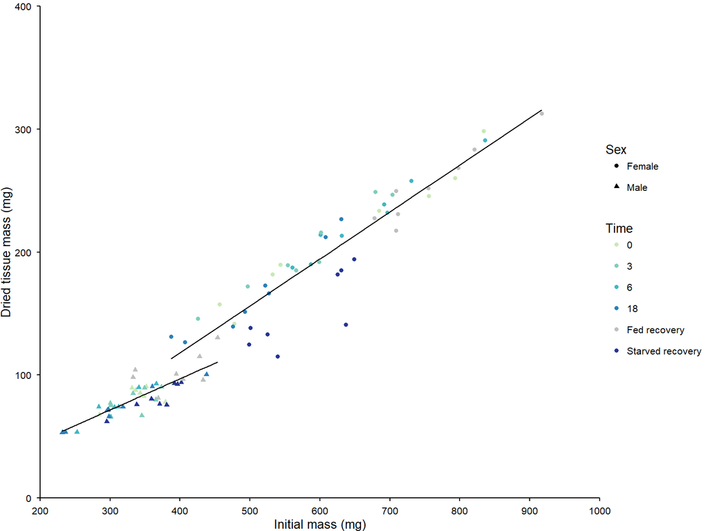

```r
tissue_data$fit <- predict(mass_cor)

p_mass_cor <- ggplot(tissue_data, aes(Start_mass, Tissue_dry_mass, colour = Time_treatment, shape = Sex)) +
  geom_point() +
  geom_line(data = tissue_data, aes(Start_mass, fit, linetype = "Sex"), colour = "black", show.legend = F, linewidth = 0.5) +
  scale_x_continuous(name = "Initial mass (mg)", expand = c(0,0), limits = c(200, 1000), breaks = seq(200,1000,  100)) +
  scale_y_continuous(name = "Dried tissue mass (mg)", expand = c(0,0), limits = c(0, 400), breaks = seq(0,1000,  100)) +
  scale_shape_manual(values = c(16, 17)) +
  scale_color_manual(name = "Time", values = c("#c7e9b4",
                                               "#7fcdbb",
"#41b6c4",
"#2c7fb8",
"grey",
"#253494"), labels = c("0", "3", "6", "18", "Fed recovery", "Starved recovery")) +
  theme(legend.position = "right", legend.title.position = "top",
        plot.margin = margin(t = 5, r = 0, b = 0, l = 0, unit = "pt"))

p_mass_cor
```

```r
ggsave(p_mass_cor, dpi = 300, width = double_width, units = "mm", height = single_height, filename = "data/Desiccation 2025/figures/fS2masscor.png")
```

Indicating that they are using fat stores or breaking down muscle.

There is a strong starting mass effect (probably a cohort effect).

```r
mean_tissue_dry <- tissue_data %>%
  group_by(Time_treatment, Sex, Time_plot) %>%
  summarise(n = n(),
            mean = mean(Tissue_dry_mass),
            se = sd(Tissue_dry_mass) / sqrt(n()),
            cv = (sd(Tissue_dry_mass) / mean) * 100)
knitr::kable(mean_tissue_dry, digits = 3)
```

| Time_treatment | Sex | Time_plot | n | mean | se | cv |
| --- | --- | --- | --- | --- | --- | --- |
| 0 | Female | 0 | 8 | 213.536 | 19.191 | 25.420 |
| 0 | Male | 0 | 8 | 84.351 | 2.879 | 9.653 |
| 3 | Female | 3 | 8 | 199.508 | 12.624 | 17.897 |
| 3 | Male | 3 | 8 | 77.259 | 4.354 | 15.941 |
| 6 | Female | 6 | 8 | 228.016 | 12.296 | 15.253 |
| 6 | Male | 6 | 8 | 74.476 | 4.430 | 16.825 |
| 18 | Female | 18 | 8 | 165.878 | 13.069 | 22.285 |
| 18 | Male | 18 | 8 | 72.714 | 5.796 | 22.546 |
| 24_fed | Female | 25 | 8 | 255.210 | 11.247 | 12.464 |
| 24_fed | Male | 25 | 8 | 102.702 | 5.140 | 14.156 |
| 24_starved | Female | 24 | 8 | 151.654 | 10.801 | 20.145 |
| 24_starved | Male | 24 | 8 | 81.375 | 3.993 | 13.877 |

```r
mean_tissue_dry_starved <- filter(mean_tissue_dry, Time_treatment != "24_fed")
mean_tissue_dry_fed <- filter(mean_tissue_dry, Time_treatment %in% c("18", "24_fed"))
```

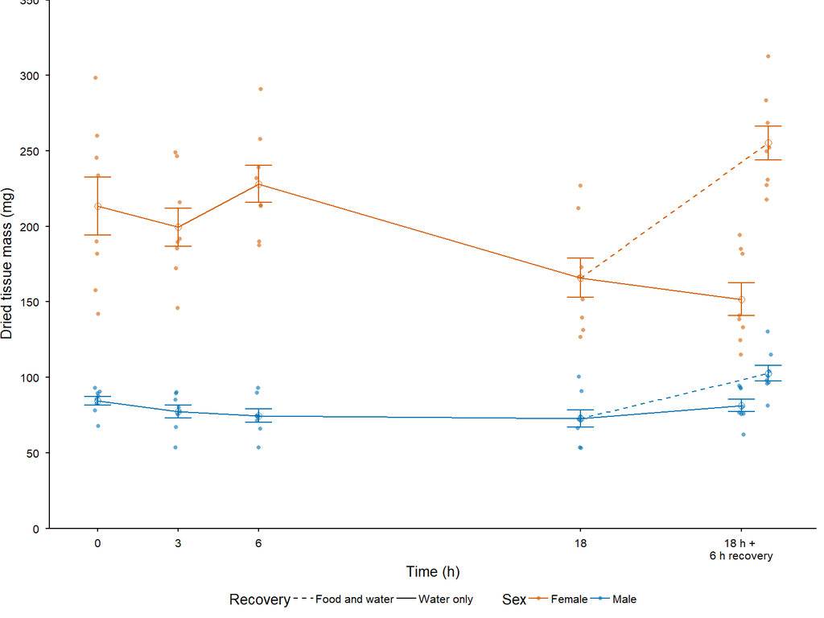

```r
p_tissue <- ggplot() +
  geom_point(data = tissue_data, aes(Time_plot, Tissue_dry_mass, shape = Sex, colour = Sex), position = position_jitter(width = 0.1, height = 0), alpha = 0.6, stroke = NA) +
   # line for starved crickets
  geom_line(data = mean_tissue_dry_starved, aes(Time_plot, mean, colour = Sex, linetype = "Starved"), linewidth = 0.5) +
   # Line for fed crickets
  geom_line(data = mean_tissue_dry_fed, aes(Time_plot, mean, colour = Sex, linetype = "Fed"), linewidth = 0.5) +
  geom_point(data = mean_tissue_dry, aes(Time_plot, mean, colour = Sex),
             size = 2, shape = 1, show.legend = FALSE) +
  geom_errorbar(data = mean_tissue_dry, aes(Time_plot, ymin = mean - se, ymax = mean + se,
                                     colour = Sex), width = 1, linewidth = 0.5) +
  scale_colour_manual(values = sex_pal) +
  scale_shape_manual(values = sex_point) +
  scale_linetype_manual(name = "Recovery", values = c("Fed" = 2, "Starved" = 1), labels = c("Food and water", "Water only")) +
  scale_y_continuous(name = expression("Dried tissue mass (mg)"), limits = c(0, 350), expand = c(0,0), breaks = seq(0, 400, 050)) +
  scale_x_continuous(name = "Time (h)", breaks = c(0, 3, 6, 18, 24), labels = c("0", "3", "6", "18", "18 h + \n6 h recovery"))

p_tissue
```

```r
ggsave(p_tissue, dpi = 300, width = ppt_width, units = "mm", height = ppt_height, filename = "data/Desiccation 2025/figures/tissue_drymass.png")
```

## 6.2 Stats: Tissue dry mass

```r
tissue_dry_mod <- lm(Tissue_dry_mass ~ Start_mass + Time_treatment + Sex + Start_mass:Sex + Start_mass:Time_treatment +Time_treatment:Sex, tissue_data)

anova(tissue_dry_mod)
```

```
Analysis of Variance Table

Response: Tissue_dry_mass
                          Df Sum Sq Mean Sq   F value                Pr(>F)
Start_mass                 1 454322  454322 4588.6829 < 0.00000000000000022 ***
Time_treatment             5  10428    2086   21.0642    0.0000000000003292 ***
Sex                        1   2057    2057   20.7727    0.0000191297201345 ***
Start_mass:Sex             1    485     485    4.8992               0.02983 *
Start_mass:Time_treatment  5   3375     675    6.8185    0.0000259139185363 ***
Time_treatment:Sex         5    964     193    1.9481               0.09598 .
Residuals                 77   7624      99
---
Signif. codes:  0 '***' 0.001 '**' 0.01 '*' 0.05 '.' 0.1 ' ' 1
```

```r
pairs(emmeans(tissue_dry_mod, ~ Time_treatment * Sex), adjust = "Tukey", by = "Sex") %>%
  broom::tidy() %>%
  filter(adj.p.value <= 0.05)
```

```
# A tibble: 4 × 9
  Sex    term           contrast        null.value estimate std.error    df
  <chr>  <chr>          <chr>                <dbl>    <dbl>     <dbl> <dbl>
1 Female Time_treatment 0 - 24_starved           0 44.25155  7.880517    77
2 Female Time_treatment 3 - 24_starved           0 47.59318  7.776804    77
3 Female Time_treatment 6 - 24_starved           0 39.88470  9.978864    77
4 Female Time_treatment 18 - 24_starved          0 40.43768  6.967848    77
  statistic adj.p.value
      <dbl>       <dbl>
1  5.615311 4.366845e-6
2  6.119889 5.390302e-7
3  3.996918 1.961954e-3
4  5.803467 2.016871e-6
```